# RM 8.5 Forecast Performance — Summer 2026

Maddee Wiggins (FlowWest)

2026-08-27

# Overview

`run-daily-forecast.R` runs once a day, predicts RM 8.5 daily max temperature and 7DADM at 1-, 3-, and 7-day lead times, and appends the predictions to `output/instream-forecast-log.csv`. This analysis focuses only on the **7DADM** predictions.

Now that real RM 8.5 logger data exists, this analysis **re-runs the 7DADM RF model** for every historical forecast date where a real RM 8.5 observation is available, using:

1. The **cached NWS forecast log** (`output/nws-forecasts-log.csv`) for air temperature / cloud cover — those can’t be re-fetched after the fact, so we reuse exactly what was forecast at the time.
2. A **fresh OWRD pull** of Camp Polk flow and temperature for the correct historical date range (not just “today”, as the operational script does).
3. The **real RM 8.5 observation** for each forecast run date, in place of the 2025 stand-in.

The model itself is the **change-from-today design** from `rm85-rf-delta.Rmd` (`rm85_rf_7dadm_delta_lead*.rds`): a separate random forest per lead (1 through 7), each trained on `rm_8_5_7dadm - dadm_m0` rather than the absolute temperature, with `dadm_m0` added back at prediction time. Anchoring on RM 8.5’s own observed value — which is identical at training and serving time — insulates the forecast from the gap between the GFS archive the model trains on and the NWS forecasts it is served, which is what previously drove a cold bias that grew with lead and concentrated above the HCP threshold. Features are Camp Polk’s current conditions and trends, the NWS trajectory from day +1 through +*k* with per-day `julian_dN`, explicit trajectory summaries, and RM 8.5’s own same-day 7DADM, Tmax and trends.

Two earlier designs are superseded and no longer loaded here: `rm85_rf_7dadm_lead_aware_lead*.rds` (Open-Meteo-trained, absolute target) and `rm85_rf_7dadm_dynamical_lead*.rds` (dynamical.org-trained, absolute target).

The resulting predictions are then compared against the real RM 8.5 observations to measure actual forecast skill: bias, MAE, RMSE, and threshold-exceedance accuracy — mirroring the threshold used operationally in `run-daily-forecast.R`.

```r
# Same threshold/station used in analysis/run-daily-forecast.R
threshold_7dadm <- 20.0
owrd_station    <- "14076100"  # Camp Polk
lead_days_vec   <- c(1:7)
trend_window    <- 5           # must match trend_window in rm85-rf-lead-aware.Rmd

# Shared color scale for lead_days plots below (blue = short lead, red = long lead)
lead_colors <- setNames(colorRampPalette(c("#185FA5", "#4E9F50", "#C93312"))(length(lead_days_vec)),
                        as.character(lead_days_vec))
```

# Read in data

```r
# Cached NWS forecast pulls — reused as-is rather than re-fetched, since past
# forecasts can't be re-requested from the NWS API.
nws_cached <- read_csv(here("output", "nws-forecasts-log.csv")) |>
  mutate(
    run_date      = as.Date(run_date),
    forecast_date = as.Date(forecast_date)
  )

rm_8_5_new <- readxl::read_xlsx(here("data-raw", "data-raw", "WC85 Rimrock bottom 2026-08-13 09_52_44 PDT.xlsx")) |>
  janitor::clean_names() |>
  glimpse()
```

```
## Rows: 3,354
## Columns: 3
## $ number        <dbl> 1, 2, 3, 4, 5, 6, 7, 8, 9, 10, 11, 12, 13, 14, 15, 16, 1…
## $ date_time_pdt <dttm> 2026-03-26 16:00:00, 2026-03-26 17:00:00, 2026-03-26 18…
## $ temperature_c <dbl> 9.295886, 9.285161, 8.856157, 8.180476, 7.558420, 6.9685…
```

# Build the RM 8.5 observed daily series

Aggregate the raw logger readings to daily statistics, the same way `rm_8_5_historical` is structured, so the two are directly comparable.

```r
rm_8_5 <- rm_8_5_new |>
  mutate(date = as.Date(lubridate::floor_date(date_time_pdt, "1 day"))) |>
  group_by(date) |>
  summarize(
    mean   = mean(temperature_c, na.rm = TRUE),
    median = median(temperature_c, na.rm = TRUE),
    max    = max(temperature_c, na.rm = TRUE),
    min    = min(temperature_c, na.rm = TRUE)
  ) |>
  mutate(
    `7DADM` = zoo::rollapply(max, width = 7, FUN = mean, fill = NA, align = "right")
  ) |>
  pivot_longer(cols = c(mean:min, `7DADM`), values_to = "temperature", names_to = "statistic") |>
  glimpse()
```

```
## Rows: 705
## Columns: 3
## $ date        <date> 2026-03-26, 2026-03-26, 2026-03-26, 2026-03-26, 2026-03-2…
## $ statistic   <chr> "mean", "median", "max", "min", "7DADM", "mean", "median",…
## $ temperature <dbl> 7.814482, 7.869448, 9.295886, 5.960381, NA, 5.782523, 5.34…
```

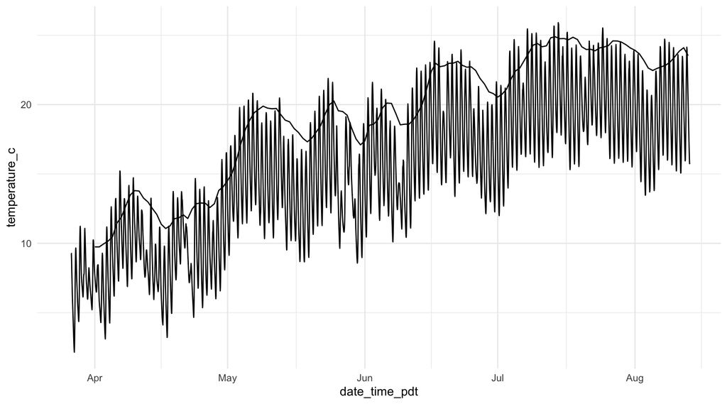

```r
ggplot() +
  geom_line(data = rm_8_5_new, aes(x = date_time_pdt, y = temperature_c)) +
  geom_line(data = rm_8_5 |> filter(statistic == "7DADM"), aes(x = date, y = temperature)) +
  theme_minimal()
```

```r
rm_8_5_wide <- rm_8_5 |>
  filter(statistic %in% c("7DADM", "max")) |>
  select(date, statistic, temperature) |>
  pivot_wider(names_from = statistic, values_from = temperature) |>
  rename(actual_7dadm_C = `7DADM`, actual_tmax_C = max)
```

# Re-running the model with real inputs

## Which forecast runs can be re-hindcast

A forecast run can only be re-hindcast if RM 8.5’s own observation for that run date exists. The models use RM 8.5’s *same-day* reading rather than the previous day’s: the operational script runs at 7pm PST and RM 8.5’s daily max lands by 5-6pm on essentially every day in this record, so today’s value is already complete at run time.

```r
hindcast_run_dates <- nws_cached |>
  distinct(run_date) |>
  filter(run_date %in% rm_8_5_wide$date) |>
  pull(run_date) |>
  sort()

cat(sprintf("Re-running %d forecast runs: %s to %s\n",
            length(hindcast_run_dates), min(hindcast_run_dates), max(hindcast_run_dates)))
```

```
## Re-running 84 forecast runs: 2026-05-04 to 2026-08-04
```

## Fresh Camp Polk pull (flow & temperature)

Pull OWRD Camp Polk flow and temperature for the historical span these forecast runs actually needed — `min(run_date) - 10` (enough lookback for a 7DADM) through `max(run_date)` — rather than the operational script’s “last 10 days from today”.

```r
pull_start <- min(hindcast_run_dates) - 10
pull_end   <- max(hindcast_run_dates)

cat(sprintf("OWRD pull window: %s to %s\n", pull_start, pull_end))
```

```
## OWRD pull window: 2026-04-24 to 2026-08-04
```

```r
cp_flow_raw <- get_owrd_hydro(owrd_station, pull_start, pull_end, "MDF")
cp_tmax_raw <- get_owrd_hydro(owrd_station, pull_start, pull_end, "WTEMP15")

cp_flow <- cp_flow_raw |>
  mutate(date = as.Date(parse_date_time(record_date, orders = c("mdy", "mdy HM")))) |>
  rename(cp_flow_mean = mean_daily_flow_cfs) |>
  select(date, cp_flow_mean) |>
  arrange(date)

cp_tmax <- cp_tmax_raw |>
  mutate(date = as.Date(parse_date_time(record_date, orders = c("mdy", "mdy HM")))) |>
  group_by(date) |>
  summarise(cp_tmax = max(instantaneous_water_temp_c, na.rm = TRUE)) |>
  arrange(date)

cp_7dadm <- cp_tmax |>
  mutate(cp_7dadm = zoo::rollmean(cp_tmax, k = 7, fill = NA, align = "right"))

cp_daily <- cp_flow |>
  left_join(cp_tmax, by = "date") |>
  left_join(select(cp_7dadm, date, cp_7dadm), by = "date")

cat(sprintf("Camp Polk daily series: %s to %s (%d days)\n",
            min(cp_daily$date), max(cp_daily$date), nrow(cp_daily)))
```

```
## Camp Polk daily series: 2026-04-24 to 2026-08-04 (103 days)
```

## Model inputs per run date & lead day

Same feature set as `rm85-rf-delta.Rmd`: Camp Polk’s current conditions (flow, 7DADM, and daily Tmax) and trends, the NWS forecast trajectory from day +1 through +*k* (stops at that row’s own lead — `dk` always lands exactly on the target date, so going further would describe weather after it), `julian_dN` paired with each trajectory day, explicit trajectory summaries, and RM 8.5’s own same-day 7DADM, Tmax and trends — sourced here from the fresh Camp Polk pull, the cached NWS log, and the real RM 8.5 record instead of live pulls and the 2025 stand-in. Unlike the historical archive used to *train* the model, `nws_cached` is real day-by-day NWS output pulled live each day, so every trajectory point here is a genuine forecast, not a proxy.

```r
safe1 <- function(x) if (length(x) == 0) NA_real_ else x

# Aggregate one cached NWS variable to a single day, the same way
# daily_nws() does in run-daily-forecast.R (max/min/mean per variable).
nws_daily <- function(var, target_date, agg_fn, run_date_val) {
  vals <- nws_cached |>
    filter(run_date == run_date_val, variable == var, forecast_date == target_date) |>
    pull(value)
  if (length(vals) == 0) return(NA_real_)
  agg_fn(vals, na.rm = TRUE)
}

# Mirrors add_trajectory_summaries() in rm85-rf-delta.Rmd — must stay in
# step with it, since the saved models were trained on these columns.
add_trajectory_summaries <- function(df, lead_k) {
  air_max_cols <- as.matrix(df[, paste0("air_max_d", 1:lead_k), drop = FALSE])
  air_min_cols <- as.matrix(df[, paste0("air_min_d", 1:lead_k), drop = FALSE])
  df$traj_air_max_max  <- apply(air_max_cols, 1, max)
  df$traj_air_max_mean <- apply(air_max_cols, 1, mean)
  df$traj_air_min_mean <- apply(air_min_cols, 1, mean)
  df$traj_warming      <- air_max_cols[, lead_k] - air_max_cols[, 1]
  df
}

build_hindcast_row <- function(run_date_val, k) {
  fdate <- run_date_val + k

  cp_today    <- cp_daily    |> filter(date == run_date_val)
  cp_yest     <- cp_daily    |> filter(date == run_date_val - 1)
  cp_trendw   <- cp_daily    |> filter(date == run_date_val - trend_window)
  rm85_today  <- rm_8_5_wide |> filter(date == run_date_val)
  rm85_trendw <- rm_8_5_wide |> filter(date == run_date_val - trend_window)

  cp_flow_m1_val  <- safe1(cp_yest$cp_flow_mean)
  cp_7dadm_m1_val <- safe1(cp_yest$cp_7dadm)

  # Only d1..dk — matches get_forecast_trajectory_dyn(lead_k) in
  # rm85-rf-delta.Rmd exactly, including the per-day julian_dN.
  traj <- map(1:k, function(d) {
    tibble(
      !!paste0("air_max_d", d) := nws_daily("maxTemperature", run_date_val + d, max,  run_date_val),
      !!paste0("air_min_d", d) := nws_daily("minTemperature", run_date_val + d, min,  run_date_val),
      !!paste0("cloud_d",   d) := nws_daily("skyCover",       run_date_val + d, mean, run_date_val),
      !!paste0("julian_d",  d) := yday(run_date_val + d)
    )
  }) |> bind_cols()

  bind_cols(
    tibble(
      run_date       = run_date_val,
      forecast_date  = fdate,
      lead_days      = k,
      cp_flow_mean   = safe1(cp_today$cp_flow_mean),
      cp_7dadm       = safe1(cp_today$cp_7dadm),
      cp_tmax        = safe1(cp_today$cp_tmax),
      cp_flow_trend  = (cp_flow_m1_val  - safe1(cp_trendw$cp_flow_mean)) / (trend_window - 1),
      cp_7dadm_trend = (cp_7dadm_m1_val - safe1(cp_trendw$cp_7dadm))     / (trend_window - 1)
    ),
    traj,
    tibble(
      dadm_m0    = safe1(rm85_today$actual_7dadm_C),
      tmax_m0    = safe1(rm85_today$actual_tmax_C),
      dadm_trend = (safe1(rm85_today$actual_7dadm_C) - safe1(rm85_trendw$actual_7dadm_C)) / trend_window,
      tmax_trend = (safe1(rm85_today$actual_tmax_C)  - safe1(rm85_trendw$actual_tmax_C))  / trend_window
    )
  )
}

hindcast_grid   <- expand_grid(run_date = hindcast_run_dates, lead_days = lead_days_vec)
hindcast_inputs <- map2_dfr(hindcast_grid$run_date, hindcast_grid$lead_days, build_hindcast_row)

# Trajectory summaries span d1..dk, so they're added per lead.
hindcast_by_lead <- map(lead_days_vec, function(k) {
  add_trajectory_summaries(hindcast_inputs |> filter(lead_days == k), k)
})
names(hindcast_by_lead) <- as.character(lead_days_vec)

cat(sprintf("Hindcast input rows: %d\n", nrow(hindcast_inputs)))
```

```
## Hindcast input rows: 588
```

## Predict

Load each lead day’s saved model once and predict across all matching rows.

**These models return a change, not a temperature.** They were trained on `rm_8_5_7dadm - dadm_m0`, so `dadm_m0` has to be added back to recover a 7DADM — that reframing is what removed most of the warm-season cold bias (see `rm85-rf-delta.Rmd`).

```r
get_model_features <- function(lead_k) {
  c("cp_flow_mean", "cp_7dadm", "cp_tmax", "cp_flow_trend", "cp_7dadm_trend",
    paste0("air_max_d", 1:lead_k), paste0("air_min_d", 1:lead_k),
    paste0("cloud_d", 1:lead_k), paste0("julian_d", 1:lead_k),
    "dadm_m0", "tmax_m0", "dadm_trend", "tmax_trend",
    "traj_air_max_max", "traj_air_max_mean", "traj_air_min_mean", "traj_warming")
}

predict_for_lead <- function(k) {
  rf_delta <- readRDS(here("output", paste0("rm85_rf_7dadm_delta_lead", k, ".rds")))

  rows     <- hindcast_by_lead[[as.character(k)]]
  features <- get_model_features(k)
  feat_x   <- rows[, c(features, "dadm_m0"), drop = FALSE]
  dadm_ok  <- complete.cases(feat_x)

  rows$pred_7dadm_C <- NA_real_
  if (any(dadm_ok)) {
    # predicted change + today's observed 7DADM = forecast 7DADM
    rows$pred_7dadm_C[dadm_ok] <- round(
      predict(rf_delta, rows[dadm_ok, , drop = FALSE]) + rows$dadm_m0[dadm_ok], 2)
  }

  rows
}

hindcast_results <- map_dfr(lead_days_vec, predict_for_lead)

cat(sprintf("Re-run predictions: %d rows (%d complete 7DADM)\n",
            nrow(hindcast_results),
            sum(!is.na(hindcast_results$pred_7dadm_C))))
```

```
## Re-run predictions: 588 rows (581 complete 7DADM)
```

# Overlap between forecasts and observed data

Performance can only be evaluated where a re-run prediction and a real observation both exist for the same `forecast_date`.

```r
obs_range <- range(rm_8_5_wide$date, na.rm = TRUE)
fc_range  <- range(hindcast_results$forecast_date, na.rm = TRUE)

cat(sprintf("RM 8.5 observed data:      %s to %s\n", obs_range[1], obs_range[2]))
```

```
## RM 8.5 observed data:      2026-03-26 to 2026-08-13
```

```r
cat(sprintf("Re-run forecast_dates:     %s to %s\n", fc_range[1], fc_range[2]))
```

```
## Re-run forecast_dates:     2026-05-05 to 2026-08-11
```

```r
forecast_eval <- hindcast_results |>
  inner_join(rm_8_5_wide, by = c("forecast_date" = "date")) |>
  filter(!is.na(actual_7dadm_C)) |>
  mutate(
    dadm_error  = pred_7dadm_C - actual_7dadm_C,
    lead_days   = factor(lead_days, levels = lead_days_vec)
  )

cat(sprintf("Forecast/observation pairs available for evaluation: %d\n", nrow(forecast_eval)))
```

```
## Forecast/observation pairs available for evaluation: 588
```

```r
forecast_eval |>
  arrange(forecast_date, lead_days) |>
  kable(digits = 2)
```

| run_date | forecast_date | lead_days | cp_flow_mean | cp_7dadm | cp_tmax | cp_flow_trend | cp_7dadm_trend | air_max_d1 | air_min_d1 | cloud_d1 | julian_d1 | dadm_m0 | tmax_m0 | dadm_trend | tmax_trend | air_max_d2 | air_min_d2 | cloud_d2 | julian_d2 | air_max_d3 | air_min_d3 | cloud_d3 | julian_d3 | air_max_d4 | air_min_d4 | cloud_d4 | julian_d4 | air_max_d5 | air_min_d5 | … |
| --- | --- | --- | --- | --- | --- | --- | --- | --- | --- | --- | --- | --- | --- | --- | --- | --- | --- | --- | --- | --- | --- | --- | --- | --- | --- | --- | --- | --- | --- | --- |
| 2026-05-04 | 2026-05-05 | 1 | 28.9 | 13.89 | 15.5 | 1.30 | NA | 25.56 | 8.89 | 9.50 | 125 | 17.20 | 19.89 | 0.68 | 0.77 | NA | NA | NA | NA | NA | NA | NA | NA | NA | NA | NA | NA | NA | NA | … |
| 2026-05-05 | 2026-05-06 | 1 | 28.5 | 14.60 | 15.8 | 1.20 | 0.57 | 27.22 | 7.78 | 19.29 | 126 | 18.20 | 20.33 | 0.82 | 0.76 | NA | NA | NA | NA | NA | NA | NA | NA | NA | NA | NA | NA | NA | NA | … |
| 2026-05-04 | 2026-05-06 | 2 | 28.9 | 13.89 | 15.5 | 1.30 | NA | 25.56 | 8.89 | 9.50 | 125 | 17.20 | 19.89 | 0.68 | 0.77 | 27.22 | 7.78 | 12.75 | 126 | NA | NA | NA | NA | NA | NA | NA | NA | NA | NA | … |
| 2026-05-06 | 2026-05-07 | 1 | 23.1 | 15.10 | 16.6 | 0.90 | 0.69 | 25.56 | 6.67 | 20.60 | 127 | 18.88 | 20.81 | 0.87 | 0.76 | NA | NA | NA | NA | NA | NA | NA | NA | NA | NA | NA | NA | NA | NA | … |
| 2026-05-05 | 2026-05-07 | 2 | 28.5 | 14.60 | 15.8 | 1.20 | 0.57 | 27.22 | 7.78 | 19.29 | 126 | 18.20 | 20.33 | 0.82 | 0.76 | 25.00 | 6.67 | 18.57 | 127 | NA | NA | NA | NA | NA | NA | NA | NA | NA | NA | … |
| 2026-05-04 | 2026-05-07 | 3 | 28.9 | 13.89 | 15.5 | 1.30 | NA | 25.56 | 8.89 | 9.50 | 125 | 17.20 | 19.89 | 0.68 | 0.77 | 27.22 | 7.78 | 12.75 | 126 | 25.56 | 7.22 | 18.71 | 127 | NA | NA | NA | NA | NA | NA | … |
| 2026-05-07 | 2026-05-08 | 1 | 28.1 | 15.41 | 15.6 | -0.70 | 0.69 | 22.78 | 5.00 | 30.27 | 128 | 19.42 | 20.28 | 0.87 | 0.50 | NA | NA | NA | NA | NA | NA | NA | NA | NA | NA | NA | NA | NA | NA | … |
| 2026-05-06 | 2026-05-08 | 2 | 23.1 | 15.10 | 16.6 | 0.90 | 0.69 | 25.56 | 6.67 | 20.60 | 127 | 18.88 | 20.81 | 0.87 | 0.76 | 22.78 | 6.11 | 34.00 | 128 | NA | NA | NA | NA | NA | NA | NA | NA | NA | NA | … |
| 2026-05-05 | 2026-05-08 | 3 | 28.5 | 14.60 | 15.8 | 1.20 | 0.57 | 27.22 | 7.78 | 19.29 | 126 | 18.20 | 20.33 | 0.82 | 0.76 | 25.00 | 6.67 | 18.57 | 127 | 21.67 | 5.56 | 33.83 | 128 | NA | NA | NA | NA | NA | NA | … |
| 2026-05-04 | 2026-05-08 | 4 | 28.9 | 13.89 | 15.5 | 1.30 | NA | 25.56 | 8.89 | 9.50 | 125 | 17.20 | 19.89 | 0.68 | 0.77 | 27.22 | 7.78 | 12.75 | 126 | 25.56 | 7.22 | 18.71 | 127 | 21.11 | 5.00 | 38.00 | 128 | NA | NA | … |
| 2026-05-08 | 2026-05-09 | 1 | 22.6 | 15.59 | 14.9 | 0.08 | 0.56 | 27.78 | 8.89 | 24.94 | 129 | 19.65 | 18.68 | 0.73 | -0.22 | NA | NA | NA | NA | NA | NA | NA | NA | NA | NA | NA | NA | NA | NA | … |
| 2026-05-07 | 2026-05-09 | 2 | 28.1 | 15.41 | 15.6 | -0.70 | 0.69 | 22.78 | 5.00 | 30.27 | 128 | 19.42 | 20.28 | 0.87 | 0.50 | 27.78 | 9.44 | 29.38 | 129 | NA | NA | NA | NA | NA | NA | NA | NA | NA | NA | … |
| 2026-05-06 | 2026-05-09 | 3 | 23.1 | 15.10 | 16.6 | 0.90 | 0.69 | 25.56 | 6.67 | 20.60 | 127 | 18.88 | 20.81 | 0.87 | 0.76 | 22.78 | 6.11 | 34.00 | 128 | 27.78 | 8.89 | 24.14 | 129 | NA | NA | NA | NA | NA | NA | … |
| 2026-05-05 | 2026-05-09 | 4 | 28.5 | 14.60 | 15.8 | 1.20 | 0.57 | 27.22 | 7.78 | 19.29 | 126 | 18.20 | 20.33 | 0.82 | 0.76 | 25.00 | 6.67 | 18.57 | 127 | 21.67 | 5.56 | 33.83 | 128 | 25.56 | 7.78 | 13.00 | 129 | NA | NA | … |
| 2026-05-04 | 2026-05-09 | 5 | 28.9 | 13.89 | 15.5 | 1.30 | NA | 25.56 | 8.89 | 9.50 | 125 | 17.20 | 19.89 | 0.68 | 0.77 | 27.22 | 7.78 | 12.75 | 126 | 25.56 | 7.22 | 18.71 | 127 | 21.11 | 5.00 | 38.00 | 128 | 22.78 | 6.11 | … |
| 2026-05-09 | 2026-05-10 | 1 | 23.3 | 15.66 | 15.3 | -1.57 | 0.43 | 26.11 | 5.00 | 55.22 | 130 | 19.89 | 19.42 | 0.54 | -0.09 | NA | NA | NA | NA | NA | NA | NA | NA | NA | NA | NA | NA | NA | NA | … |
| 2026-05-08 | 2026-05-10 | 2 | 22.6 | 15.59 | 14.9 | 0.08 | 0.56 | 27.78 | 8.89 | 24.94 | 129 | 19.65 | 18.68 | 0.73 | -0.22 | 26.11 | 5.00 | 39.12 | 130 | NA | NA | NA | NA | NA | NA | NA | NA | NA | NA | … |
| 2026-05-07 | 2026-05-10 | 3 | 28.1 | 15.41 | 15.6 | -0.70 | 0.69 | 22.78 | 5.00 | 30.27 | 128 | 19.42 | 20.28 | 0.87 | 0.50 | 27.78 | 9.44 | 29.38 | 129 | 25.56 | 5.56 | 32.88 | 130 | NA | NA | NA | NA | NA | NA | … |
| 2026-05-06 | 2026-05-10 | 4 | 23.1 | 15.10 | 16.6 | 0.90 | 0.69 | 25.56 | 6.67 | 20.60 | 127 | 18.88 | 20.81 | 0.87 | 0.76 | 22.78 | 6.11 | 34.00 | 128 | 27.78 | 8.89 | 24.14 | 129 | 27.22 | 7.22 | 33.25 | 130 | NA | NA | … |
| 2026-05-05 | 2026-05-10 | 5 | 28.5 | 14.60 | 15.8 | 1.20 | 0.57 | 27.22 | 7.78 | 19.29 | 126 | 18.20 | 20.33 | 0.82 | 0.76 | 25.00 | 6.67 | 18.57 | 127 | 21.67 | 5.56 | 33.83 | 128 | 25.56 | 7.78 | 13.00 | 129 | 28.89 | 8.89 | … |
| 2026-05-04 | 2026-05-10 | 6 | 28.9 | 13.89 | 15.5 | 1.30 | NA | 25.56 | 8.89 | 9.50 | 125 | 17.20 | 19.89 | 0.68 | 0.77 | 27.22 | 7.78 | 12.75 | 126 | 25.56 | 7.22 | 18.71 | 127 | 21.11 | 5.00 | 38.00 | 128 | 22.78 | 6.11 | … |
| 2026-05-09 | 2026-05-11 | 2 | 23.3 | 15.66 | 15.3 | -1.57 | 0.43 | 26.11 | 5.00 | 55.22 | 130 | 19.89 | 19.42 | 0.54 | -0.09 | 27.22 | 8.89 | 25.00 | 131 | NA | NA | NA | NA | NA | NA | NA | NA | NA | NA | … |
| 2026-05-08 | 2026-05-11 | 3 | 22.6 | 15.59 | 14.9 | 0.08 | 0.56 | 27.78 | 8.89 | 24.94 | 129 | 19.65 | 18.68 | 0.73 | -0.22 | 26.11 | 5.00 | 39.12 | 130 | 27.78 | 9.44 | 18.57 | 131 | NA | NA | NA | NA | NA | NA | … |
| 2026-05-07 | 2026-05-11 | 4 | 28.1 | 15.41 | 15.6 | -0.70 | 0.69 | 22.78 | 5.00 | 30.27 | 128 | 19.42 | 20.28 | 0.87 | 0.50 | 27.78 | 9.44 | 29.38 | 129 | 25.56 | 5.56 | 32.88 | 130 | 27.22 | 8.33 | 14.71 | 131 | NA | NA | … |
| 2026-05-06 | 2026-05-11 | 5 | 23.1 | 15.10 | 16.6 | 0.90 | 0.69 | 25.56 | 6.67 | 20.60 | 127 | 18.88 | 20.81 | 0.87 | 0.76 | 22.78 | 6.11 | 34.00 | 128 | 27.78 | 8.89 | 24.14 | 129 | 27.22 | 7.22 | 33.25 | 130 | 27.22 | 7.78 | … |
| 2026-05-05 | 2026-05-11 | 6 | 28.5 | 14.60 | 15.8 | 1.20 | 0.57 | 27.22 | 7.78 | 19.29 | 126 | 18.20 | 20.33 | 0.82 | 0.76 | 25.00 | 6.67 | 18.57 | 127 | 21.67 | 5.56 | 33.83 | 128 | 25.56 | 7.78 | 13.00 | 129 | 28.89 | 8.89 | … |
| 2026-05-04 | 2026-05-11 | 7 | 28.9 | 13.89 | 15.5 | 1.30 | NA | 25.56 | 8.89 | 9.50 | 125 | 17.20 | 19.89 | 0.68 | 0.77 | 27.22 | 7.78 | 12.75 | 126 | 25.56 | 7.22 | 18.71 | 127 | 21.11 | 5.00 | 38.00 | 128 | 22.78 | 6.11 | … |
| 2026-05-11 | 2026-05-12 | 1 | 25.5 | 15.66 | 15.8 | 0.12 | 0.13 | 30.00 | 7.22 | 41.94 | 132 | 19.70 | 19.55 | 0.16 | -0.25 | NA | NA | NA | NA | NA | NA | NA | NA | NA | NA | NA | NA | NA | NA | … |
| 2026-05-09 | 2026-05-12 | 3 | 23.3 | 15.66 | 15.3 | -1.57 | 0.43 | 26.11 | 5.00 | 55.22 | 130 | 19.89 | 19.42 | 0.54 | -0.09 | 27.22 | 8.89 | 25.00 | 131 | 31.11 | 10.56 | 37.29 | 132 | NA | NA | NA | NA | NA | NA | … |
| 2026-05-08 | 2026-05-12 | 4 | 22.6 | 15.59 | 14.9 | 0.08 | 0.56 | 27.78 | 8.89 | 24.94 | 129 | 19.65 | 18.68 | 0.73 | -0.22 | 26.11 | 5.00 | 39.12 | 130 | 27.78 | 9.44 | 18.57 | 131 | 30.00 | 9.44 | 34.75 | 132 | NA | NA | … |

[output cut: 558 more lines]

# Error metrics by lead day

```r
metrics_by_lead <- forecast_eval |>
  group_by(lead_days) |>
  summarise(
    n              = n(),
    dadm_bias      = mean(dadm_error, na.rm = TRUE),
    dadm_mae       = mean(abs(dadm_error), na.rm = TRUE),
    dadm_rmse      = sqrt(mean(dadm_error^2, na.rm = TRUE)),
    dadm_cor       = cor(pred_7dadm_C, actual_7dadm_C, use = "complete.obs"),
    .groups = "drop"
  )

metrics_by_lead |>
  kable(digits = 2,
        col.names = c("Lead (days)", "n",
                      "7DADM bias", "7DADM MAE", "7DADM RMSE", "7DADM r"))
```

| Lead (days) | n | 7DADM bias | 7DADM MAE | 7DADM RMSE | 7DADM r |
| --- | --- | --- | --- | --- | --- |
| 1 | 84 | -0.05 | 0.21 | 0.27 | 0.99 |
| 2 | 84 | -0.01 | 0.32 | 0.41 | 0.99 |
| 3 | 84 | -0.01 | 0.44 | 0.54 | 0.97 |
| 4 | 84 | -0.02 | 0.58 | 0.74 | 0.95 |
| 5 | 84 | -0.07 | 0.70 | 0.88 | 0.93 |
| 6 | 84 | -0.07 | 0.79 | 1.01 | 0.91 |
| 7 | 84 | -0.19 | 0.81 | 1.01 | 0.91 |

Positive bias means the model runs warm (over-predicts); negative bias means it runs cold. MAE/RMSE are in °C.

# Threshold-exceedance performance

Beyond raw temperature error, the operational value of the forecast is whether it correctly flags days that cross the HCP action threshold (7DADM ≥ 20°C).

```r
exceedance_eval <- forecast_eval |>
  mutate(
    pred_exceed_7dadm   = pred_7dadm_C   >= threshold_7dadm,
    actual_exceed_7dadm = actual_7dadm_C >= threshold_7dadm
  )

confusion_summary <- function(df, pred_col, actual_col) {
  df <- df |> filter(!is.na({{ pred_col }}), !is.na({{ actual_col }}))
  tp <- sum(df[[deparse(substitute(pred_col))]]  & df[[deparse(substitute(actual_col))]])
  tn <- sum(!df[[deparse(substitute(pred_col))]] & !df[[deparse(substitute(actual_col))]])
  fp <- sum(df[[deparse(substitute(pred_col))]]  & !df[[deparse(substitute(actual_col))]])
  fn <- sum(!df[[deparse(substitute(pred_col))]] & df[[deparse(substitute(actual_col))]])

  tibble(
    n           = nrow(df),
    accuracy    = (tp + tn) / nrow(df),
    sensitivity = if (tp + fn > 0) tp / (tp + fn) else NA_real_,
    specificity = if (tn + fp > 0) tn / (tn + fp) else NA_real_,
    precision   = if (tp + fp > 0) tp / (tp + fp) else NA_real_
  )
}

exceedance_by_lead <- exceedance_eval |>
  group_by(lead_days) |>
  group_modify(~ confusion_summary(.x, pred_exceed_7dadm, actual_exceed_7dadm)) |>
  ungroup()

exceedance_by_lead |>
  kable(digits = 2,
        col.names = c("Lead (days)", "n", "Accuracy", "Sensitivity", "Specificity", "Precision"))
```

| Lead (days) | n | Accuracy | Sensitivity | Specificity | Precision |
| --- | --- | --- | --- | --- | --- |
| 1 | 83 | 0.95 | 0.94 | 0.97 | 0.98 |
| 2 | 83 | 0.94 | 0.96 | 0.91 | 0.94 |
| 3 | 83 | 0.89 | 0.92 | 0.84 | 0.90 |
| 4 | 83 | 0.89 | 0.92 | 0.84 | 0.91 |
| 5 | 83 | 0.89 | 0.91 | 0.87 | 0.92 |
| 6 | 83 | 0.89 | 0.91 | 0.86 | 0.92 |
| 7 | 83 | 0.92 | 0.93 | 0.89 | 0.94 |

# Predicted vs. observed

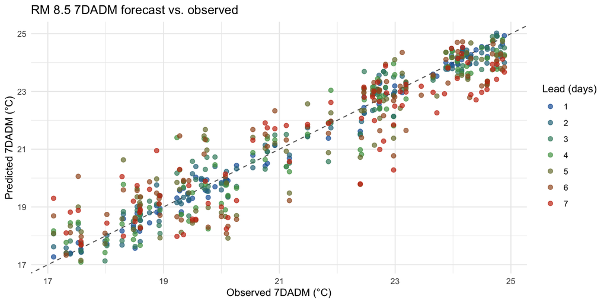

```r
forecast_eval |>
  ggplot(aes(x = actual_7dadm_C, y = pred_7dadm_C, color = lead_days)) +
  geom_abline(slope = 1, intercept = 0, linetype = "dashed", color = "#666666") +
  geom_point(size = 2, alpha = 0.7) +
  scale_color_manual(values = lead_colors) +
  labs(
    title = "RM 8.5 7DADM forecast vs. observed",
    x = "Observed 7DADM (°C)", y = "Predicted 7DADM (°C)", color = "Lead (days)"
  ) +
  theme_minimal()
```

# Forecast vs. observed over time

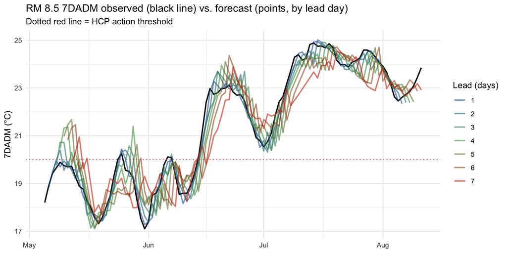

```r
observed_7dadm <- rm_8_5_wide |>
  filter(date >= min(forecast_eval$forecast_date), date <= max(forecast_eval$forecast_date))

ggplot() +
  geom_line(data = observed_7dadm, aes(x = date, y = actual_7dadm_C), color = "black", linewidth = 0.8) +
  geom_line(data = forecast_eval, aes(x = forecast_date, y = pred_7dadm_C, color = lead_days), size = 0.8, alpha = 0.6) +
  geom_hline(yintercept = threshold_7dadm, linetype = "dotted", color = "#E24B4A") +
  scale_color_manual(values = lead_colors) +
  labs(
    title = "RM 8.5 7DADM observed (black line) vs. forecast (points, by lead day)",
    subtitle = "Dotted red line = HCP action threshold",
    x = NULL, y = "7DADM (°C)", color = "Lead (days)"
  ) +
  theme_minimal()
```

# Forecast error by lead day

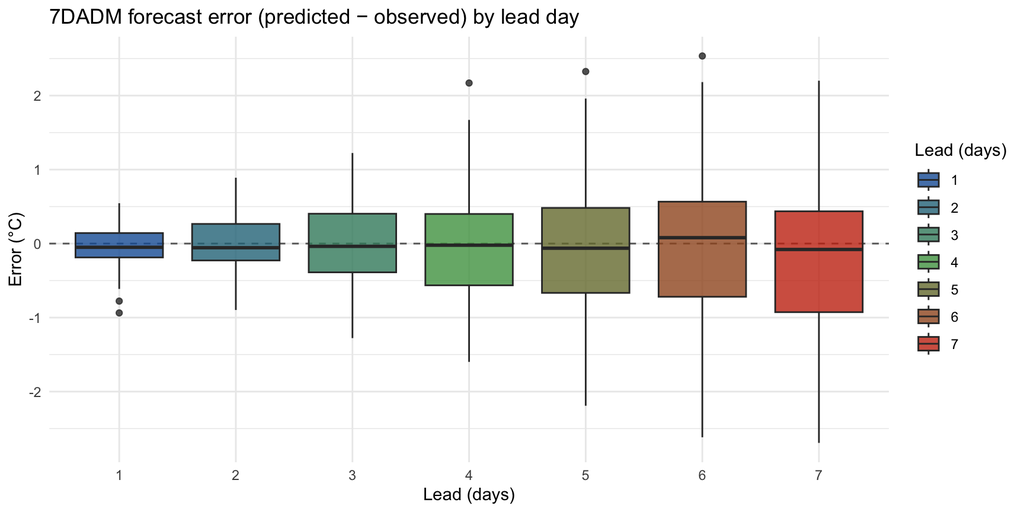

```r
forecast_eval |>
  ggplot(aes(x = lead_days, y = dadm_error, fill = lead_days)) +
  geom_hline(yintercept = 0, linetype = "dashed", color = "#666666") +
  geom_boxplot(alpha = 0.8) +
  scale_fill_manual(values = lead_colors) +
  labs(
    title = "7DADM forecast error (predicted − observed) by lead day",
    x = "Lead (days)", y = "Error (°C)", fill = "Lead (days)"
  ) +
  theme_minimal()
```